# K-Means

# Mise en place de k-means avec le (k=3) clusters optimaux

```r
#make this example reproducible
set.seed(1)

#perform k-means clustering with k = 4 clusters
km <- kmeans(df, centers = 3, nstart = 25)

#view results
km
```

```
## K-means clustering with 3 clusters of sizes 53, 47, 50
##
## Cluster means:
##   Sepal.Length Sepal.Width Petal.Length Petal.Width
## 1  -0.05005221 -0.88042696    0.3465767   0.2805873
## 2   1.13217737  0.08812645    0.9928284   1.0141287
## 3  -1.01119138  0.85041372   -1.3006301  -1.2507035
##
## Clustering vector:
##   [1] 3 3 3 3 3 3 3 3 3 3 3 3 3 3 3 3 3 3 3 3 3 3 3 3 3 3 3 3 3 3 3 3 3 3 3 3 3
##  [38] 3 3 3 3 3 3 3 3 3 3 3 3 3 2 2 2 1 1 1 2 1 1 1 1 1 1 1 1 2 1 1 1 1 2 1 1 1
##  [75] 1 2 2 2 1 1 1 1 1 1 1 2 2 1 1 1 1 1 1 1 1 1 1 1 1 1 2 1 2 2 2 2 1 2 2 2 2
## [112] 2 2 1 1 2 2 2 2 1 2 1 2 1 2 2 1 2 2 2 2 2 2 1 1 2 2 2 1 2 2 2 1 2 2 2 1 2
## [149] 2 1
##
## Within cluster sum of squares by cluster:
## [1] 44.08754 47.45019 47.35062
##  (between_SS / total_SS =  76.7 %)
##
## Available components:
##
## [1] "cluster"      "centers"      "totss"        "withinss"     "tot.withinss"
## [6] "betweenss"    "size"         "iter"         "ifault"
```

Les résultats montrent que:

53 élément dans le premier groupe

47 élément dans le deuxième groupe

50 élément dans le troisième groupe

Nous pouvons visualiser les grappes sur un nuage de points qui affiche les deux premières composantes principales sur les axes à l’aide de la fonction fivz_cluster()

# Visualiser les clusters

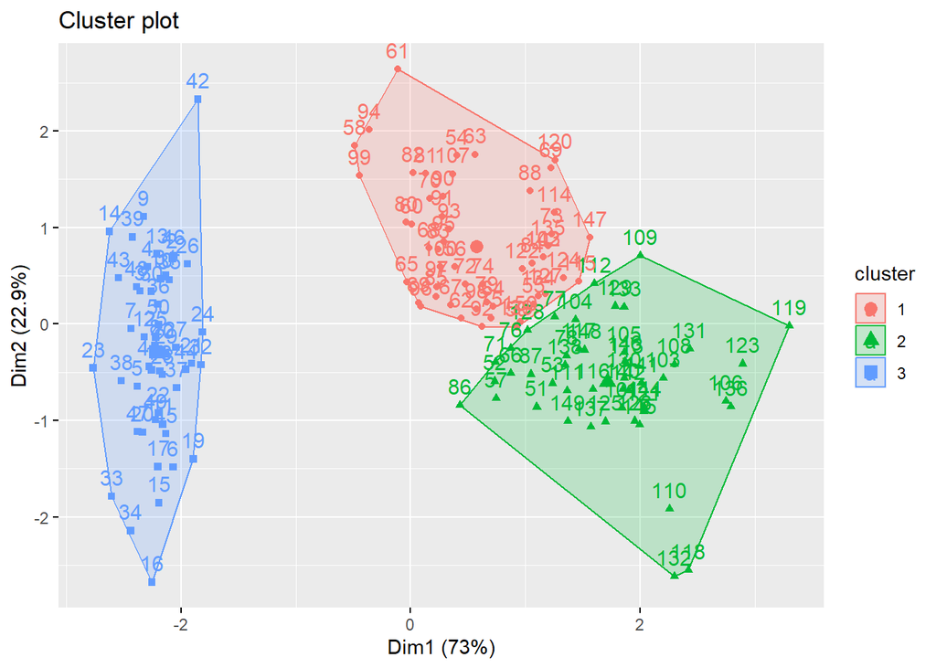

```r
#plot results of final k-means model
fviz_cluster(km, data = df)
```

Nous pouvons également utiliser la fonction aggregate() pour trouver la moyenne des variables dans chaque groupe :

```r
#find means of each cluster
aggregate(iris, by=list(cluster=km$cluster), mean)
```

```
##   cluster Sepal.Length Sepal.Width Petal.Length Petal.Width Species
## 1       1     5.801887    2.673585     4.369811    1.413208      NA
## 2       2     6.780851    3.095745     5.510638    1.972340      NA
## 3       3     5.006000    3.428000     1.462000    0.246000      NA
```

```r
#add cluster assigment to original data
final_data <- cbind(iris, cluster = km$cluster)

#view final data
head(final_data)
```

```
##   Sepal.Length Sepal.Width Petal.Length Petal.Width Species cluster
## 1          5.1         3.5          1.4         0.2  setosa       3
## 2          4.9         3.0          1.4         0.2  setosa       3
## 3          4.7         3.2          1.3         0.2  setosa       3
## 4          4.6         3.1          1.5         0.2  setosa       3
## 5          5.0         3.6          1.4         0.2  setosa       3
## 6          5.4         3.9          1.7         0.4  setosa       3
```